# Arbitrage between gold futures traded in Brazil and USA

Both Brazil's Bovespa Exchange and Chicago Commodities Exchange have future contracts for Gold. In Brazil, it is called OZ1D and in USA it is called GC. Since gold is a world commoditie, its price should be the same in all trade markets after FX effects. However, it is not always true. Although gold futures prices are correlated in both markets, on some days arbitrage opportunities occur because of difference in the markets, and it can be because of its size, on special player making a movement, and other technical aspects.

On this article, we will see how to identifiy these arbitrage opportunities using python. We start by importing all libraries we will need on our work

```python
#Importing libraries
import pandas as pd
import numpy as np
import matplotlib.pyplot as plt
```

Data was collected from investing.com. We collected historical data from GC prices, OZ1D prices, as well as USD / BRL FX. Once GC is traded in dollars and OZ1D is traded in BRL, we will convert the prices of GC to BRL based on USD / BRL. So let's read our .csv files to databases.

```python
#reading data seaved on .csv
GC_raw=pd.read_csv('GC_investing.csv',parse_dates=['Date'])
OZ_raw=pd.read_csv('OZ_investing.csv',parse_dates=['Date'])
USD_BRL=pd.read_csv('USD_BRL_investing.csv',parse_dates=['Date'])
```

```python
GC_raw.head()
```

|  | Date | Price | Open | High | Low | Vol. | Change % |
| --- | --- | --- | --- | --- | --- | --- | --- |
| 0 | 2020-05-04 | 1,713.40 | 1,707.15 | 1,725.30 | 1,702.40 | - | 0.36% |
| 1 | 2020-05-03 | 1,707.20 | 1,710.15 | 1,711.60 | 1,700.50 | - | 0.37% |
| 2 | 2020-05-01 | 1,700.90 | 1,693.50 | 1,714.40 | 1,676.00 | - | 0.40% |
| 3 | 2020-04-30 | 1,694.20 | 1,729.60 | 1,737.00 | 1,687.50 | - | -1.12% |
| 4 | 2020-04-29 | 1,713.40 | 1,724.80 | 1,733.50 | 1,708.20 | - | -0.51% |

```python
OZ_raw.head()
```

|  | Date | Price | Open | High | Low | Vol. | Change % |
| --- | --- | --- | --- | --- | --- | --- | --- |
| 0 | 2020-04-30 | 295.40 | 295.40 | 295.40 | 295.40 | - | 1.50% |
| 1 | 2020-04-29 | 291.04 | 291.04 | 291.04 | 291.04 | - | -3.97% |
| 2 | 2020-04-28 | 303.09 | 303.09 | 303.09 | 303.09 | - | -4.73% |
| 3 | 2020-04-27 | 318.14 | 318.14 | 318.14 | 318.14 | - | 0.93% |
| 4 | 2020-04-24 | 315.19 | 315.19 | 315.19 | 315.19 | - | -3.09% |

```python
USD_BRL.head()
```

|  | Date | Price | Open | High | Low | Change % |
| --- | --- | --- | --- | --- | --- | --- |
| 0 | 2020-05-04 | 5.5459 | 5.6141 | 5.6143 | 5.5187 | 1.09% |
| 1 | 2020-05-01 | 5.4861 | 5.4861 | 5.4861 | 5.4861 | -0.03% |
| 2 | 2020-04-30 | 5.4875 | 5.3346 | 5.4875 | 5.3306 | 2.84% |
| 3 | 2020-04-29 | 5.3361 | 5.5019 | 5.5280 | 5.3340 | -3.00% |
| 4 | 2020-04-28 | 5.5012 | 5.6085 | 5.6221 | 5.4710 | -2.71% |

For each of these dataframes, we will work with 'Price' column, that refers to closing price of the contract on each datu. As we can see on dataframes above, 'Price' values on GC_raw have a comma, turning it to a string. Also, 'Change %' has a '%' charachter, turning it to string. We will make the adjustments to have only numerical data.

```python
priceNumeric = []
changeFloat=[]

for i in range(0,len(GC_raw)):
    priceNumeric.append(float(GC_raw.iloc[i]['Price'].replace(',','')))
    changeFloat.append(float(GC_raw.iloc[i]['Change %'].replace('%','')))

GC_raw['Price Numeric']=priceNumeric
GC_raw['Change float']=changeFloat

changeFloat=[]
for i in range(0,len(OZ_raw)):
    changeFloat.append(float(OZ_raw.iloc[i]['Change %'].replace('%','')))

OZ_raw['Change float']=changeFloat

GC_raw.head()
```

|  | Date | Price | Open | High | Low | Vol. | Change % | Price Numeric | Change float |
| --- | --- | --- | --- | --- | --- | --- | --- | --- | --- |
| 0 | 2020-05-04 | 1,713.40 | 1,707.15 | 1,725.30 | 1,702.40 | - | 0.36% | 1713.4 | 0.36 |
| 1 | 2020-05-03 | 1,707.20 | 1,710.15 | 1,711.60 | 1,700.50 | - | 0.37% | 1707.2 | 0.37 |
| 2 | 2020-05-01 | 1,700.90 | 1,693.50 | 1,714.40 | 1,676.00 | - | 0.40% | 1700.9 | 0.40 |
| 3 | 2020-04-30 | 1,694.20 | 1,729.60 | 1,737.00 | 1,687.50 | - | -1.12% | 1694.2 | -1.12 |
| 4 | 2020-04-29 | 1,713.40 | 1,724.80 | 1,733.50 | 1,708.20 | - | -0.51% | 1713.4 | -0.51 |

We will also adjust 'Date' column on the dataframes to have it order from early to later periods and then make 'Date' column our index.

```python
#Order date in ascending order
GC = GC_raw.sort_index(axis=0,ascending=False)
OZ = OZ_raw.sort_index(axis=0,ascending=False)
USD_BRL = USD_BRL.sort_index(axis=0,ascending=False)

#Make date index
GC=GC.set_index('Date')
OZ=OZ.set_index('Date')
USD_BRL=USD_BRL.set_index('Date')

GC.head()
```

| Date | Price | Open | High | Low | Vol. | Change % | Price Numeric | Change float |
| --- | --- | --- | --- | --- | --- | --- | --- | --- |
| 2018-04-04 | 1,335.80 | 1,331.80 | 1,347.30 | 1,331.60 | 0.72K | 0.23% | 1335.8 | 0.23 |
| 2018-04-05 | 1,324.30 | 1,333.50 | 1,333.70 | 1,322.60 | 0.26K | -0.86% | 1324.3 | -0.86 |
| 2018-04-06 | 1,331.90 | 1,326.50 | 1,333.00 | 1,319.00 | 0.35K | 0.57% | 1331.9 | 0.57 |
| 2018-04-09 | 1,336.30 | 1,333.00 | 1,337.50 | 1,327.00 | 0.29K | 0.33% | 1336.3 | 0.33 |
| 2018-04-10 | 1,342.00 | 1,335.20 | 1,341.00 | 1,333.00 | 0.11K | 0.43% | 1342.0 | 0.43 |

Now, we can merge our three databases keeping only its price columns, that will be used on our analysis

```python
#Merging databases by data column
GCOZ=pd.merge(GC['Price Numeric'],OZ['Price'],on='Date')
GCOZ=pd.merge(GCOZ,USD_BRL['Price'],on='Date')

#Adjusting column names
GCOZ=GCOZ.rename(columns={'Price Numeric':'Price GC','Price_x':'Price OZ','Price_y':'USD_BRL'})
GCOZ.head()
```

| Date | Price GC | Price OZ | USD_BRL |
| --- | --- | --- | --- |
| 2018-04-04 | 1335.8 | 143.93 | 3.3297 |
| 2018-04-05 | 1324.3 | 142.09 | 3.3449 |
| 2018-04-06 | 1331.9 | 145.56 | 3.3697 |
| 2018-04-09 | 1336.3 | 146.54 | 3.4200 |
| 2018-04-10 | 1342.0 | 146.50 | 3.4088 |

Now we can multiply the closing price of GC by the FX rate USD / BRL to adjust the price to BRL. Then, all our analyisis will occur on BRL.

```python
GCOZ['GC_BRL']=GCOZ['Price GC']*GCOZ['USD_BRL']
GCOZ.head()
```

| Date | Price GC | Price OZ | USD_BRL | GC_BRL |
| --- | --- | --- | --- | --- |
| 2018-04-04 | 1335.8 | 143.93 | 3.3297 | 4447.81326 |
| 2018-04-05 | 1324.3 | 142.09 | 3.3449 | 4429.65107 |
| 2018-04-06 | 1331.9 | 145.56 | 3.3697 | 4488.10343 |
| 2018-04-09 | 1336.3 | 146.54 | 3.4200 | 4570.14600 |
| 2018-04-10 | 1342.0 | 146.50 | 3.4088 | 4574.60960 |

```python
GC_div_oz = GCOZ['GC_BRL'] / GCOZ['Price OZ']
GC_div_oz.head()
```

```
Date
2018-04-04    30.902614
2018-04-05    31.174967
2018-04-06    30.833357
2018-04-09    31.187021
2018-04-10    31.226004
dtype: float64
```

```python
import statistics

#Calculating mean
mean_period = 72
div_mean = []

for i in range(0,len(GC_div_oz)):
    if i<mean_period:
        div_mean.append(0)
    else:
        div_mean.append(statistics.mean(GC_div_oz[i-21:i]))

#Calculating standard deviation
std = np.std(GC_div_oz)

mean_plus_dev = []
mean_minus_dev = []

for i in range(0,len(div_mean)):
    if div_mean[i]==0:
        mean_plus_dev.append(0)
        mean_minus_dev.append(0)
    else:
        mean_plus_dev.append(div_mean[i]+0.5*std)
        mean_minus_dev.append(div_mean[i]-0.5*std)
```

We create a database called "Mean_data" with statiscs data we just created. This is the data we will plot and analysis.

```python
Mean_data=pd.DataFrame(columns=['Mean','Mean + std dev','Mean - std dev'])
Mean_data['Mean']=div_mean
GC_div_oz_array=np.array(GC_div_oz)
Mean_data['Mean + std dev']=mean_plus_dev
Mean_data['Mean - std dev']=mean_minus_dev
Mean_data['Date']=GCOZ.index
Mean_data['GC / OZ']=GC_div_oz_array
Mean_data=Mean_data.set_index('Date')
Mean_data.head(75)
```

| Date | Mean | Mean + std dev | Mean - std dev | GC / OZ |
| --- | --- | --- | --- | --- |
| 2018-04-04 | 0.000000 | 0.000000 | 0.000000 | 30.902614 |
| 2018-04-05 | 0.000000 | 0.000000 | 0.000000 | 31.174967 |
| 2018-04-06 | 0.000000 | 0.000000 | 0.000000 | 30.833357 |
| 2018-04-09 | 0.000000 | 0.000000 | 0.000000 | 31.187021 |
| 2018-04-10 | 0.000000 | 0.000000 | 0.000000 | 31.226004 |
| ... | ... | ... | ... | ... |
| 2018-07-16 | 0.000000 | 0.000000 | 0.000000 | 31.156281 |
| 2018-07-17 | 0.000000 | 0.000000 | 0.000000 | 31.187228 |
| 2018-07-18 | 30.885689 | 31.278996 | 30.492382 | 31.405284 |
| 2018-07-19 | 30.922898 | 31.316205 | 30.529591 | 30.939728 |
| 2018-07-20 | 30.972056 | 31.365363 | 30.578750 | 31.059795 |

75 rows × 4 columns

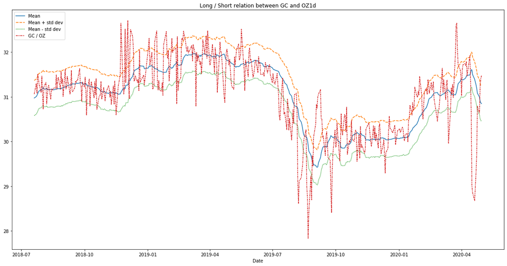

```python
import seaborn as sns
plt.figure(figsize=(20,10))
plt.title('Long / Short relation between GC and OZ1d')
sns.lineplot(data=Mean_data.loc['2018-07-20':,:])
```

```python
#Creating columns for GC and OZ price on Mean_data
Mean_data['GC price']=GCOZ['GC_BRL']
Mean_data['OZ price']=GCOZ['Price OZ']
```

```python
operations = pd.DataFrame(columns=['Date Start','Asset to buy','Price asset to buy','Asset to sell','Price asset to sell',
                                  'GC / OZ Start','Date end','Price asset bought','Price asset sold','GC / OZ End'])
start=0

dateStart=[]
assetToBuy=[]
priceAssetToBuy=[]
assetToSell=[]
priceAssetToSell=[]
GCOZstart=[]
dateEnd=[]
priceAssetBought=[]
priceAssetSold=[]
GCOZend=[]



for i in range(0,len(Mean_data)):

    if Mean_data.iloc[i]['Mean']!=0:
        if start==0:
            if Mean_data.iloc[i]['GC / OZ']>Mean_data.iloc[i]['Mean + std dev']:
                dateStart.append(Mean_data.index[i])
                assetToBuy.append('OZ')
                priceAssetToBuy.append(Mean_data.iloc[i]['OZ price'])
                assetToSell.append('GC')
                priceAssetToSell.append(Mean_data.iloc[i]['GC price'])
                GCOZstart.append(Mean_data.iloc[i]['GC / OZ'])
                start =1

            if Mean_data.iloc[i]['GC / OZ']<Mean_data.iloc[i]['Mean - std dev']:
                dateStart.append(Mean_data.index[i])
                assetToBuy.append('GC')
                priceAssetToBuy.append(Mean_data.iloc[i]['GC price'])
                assetToSell.append('OZ')
                priceAssetToSell.append(Mean_data.iloc[i]['OZ price'])
                GCOZstart.append(Mean_data.iloc[i]['GC / OZ'])
                start = 2
        if start==1:
            if Mean_data.iloc[i]['GC / OZ']<=Mean_data.iloc[i]['Mean']:
                dateEnd.append(Mean_data.index[i])
                priceAssetBought.append(Mean_data.iloc[i]['OZ price'])
                priceAssetSold.append(Mean_data.iloc[i]['GC price'])
                GCOZend.append(Mean_data.iloc[i]['GC / OZ'])
                start = 0

        if start==2:
            if Mean_data.iloc[i]['GC / OZ']>=Mean_data.iloc[i]['Mean']:
                dateEnd.append(Mean_data.index[i])
                priceAssetBought.append(Mean_data.iloc[i]['GC price'])
                priceAssetSold.append(Mean_data.iloc[i]['OZ price'])
                GCOZend.append(Mean_data.iloc[i]['GC / OZ'])
                start = 0

dateEnd.append(Mean_data.index[-1])
priceAssetBought.append(Mean_data.iloc[-1]['GC price'])
priceAssetSold.append(Mean_data.iloc[-1]['OZ price'])
GCOZend.append(Mean_data.iloc[-1]['GC / OZ'])

operations['Date Start']=dateStart
operations['Asset to buy']=assetToBuy
operations['Price asset to buy']=priceAssetToBuy
operations['Asset to sell']=assetToSell
operations['Price asset to sell']=priceAssetToSell
operations['GC / OZ Start']=GCOZstart
operations['Date end']=dateEnd
operations['Price asset bought']=priceAssetBought
operations['Price asset sold']=priceAssetSold
operations['GC / OZ End']=GCOZend

operations.head()
```

|  | Date Start | Asset to buy | Price asset to buy | Asset to sell | Price asset to sell | GC / OZ Start | Date end | Price asset bought | Price asset sold | GC / OZ End |
| --- | --- | --- | --- | --- | --- | --- | --- | --- | --- | --- |
| 0 | 2018-07-18 | OZ | 150.38000 | GC | 4722.72656 | 31.405284 | 2018-07-30 | 146.54000 | 4556.30391 | 31.092561 |
| 1 | 2018-08-02 | GC | 4540.11318 | OZ | 147.76000 | 30.726267 | 2018-08-03 | 4502.25360 | 144.21000 | 31.220121 |
| 2 | 2018-09-27 | GC | 4743.74229 | OZ | 153.54000 | 30.895808 | 2018-09-28 | 4824.50265 | 154.00000 | 31.327939 |
| 3 | 2018-10-04 | GC | 4638.55140 | OZ | 151.67000 | 30.583183 | 2018-10-08 | 4475.84760 | 142.56000 | 31.396237 |
| 4 | 2018-10-09 | GC | 4411.04160 | OZ | 143.23000 | 30.796911 | 2018-10-11 | 4626.29820 | 147.62000 | 31.339237 |

With this dataset of operations, we can create a new dataframe called signals, and store the date, ratio and if it is the start or end of operation. Plotting signals to our average graph can help to understand when the arbitrage opportunity starts and when the ratio return to its mean.

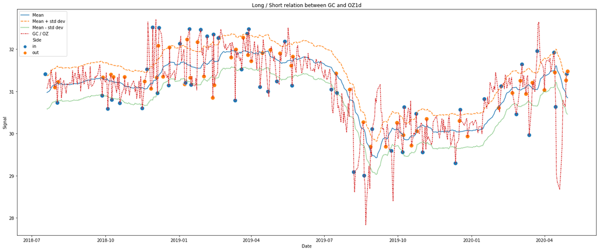

```python
signals=pd.DataFrame(columns=['Date','Signal','Side'])
date=[]
GCOZ=[]
side=[]

for i in range(0,len(operations)):
    date.append(operations.iloc[i]['Date Start'])
    date.append(operations.iloc[i]['Date end'])
    GCOZ.append(operations.iloc[i]['GC / OZ Start'])
    GCOZ.append(operations.iloc[i]['GC / OZ End'])
    side.append('in')
    side.append('out')


signals['Date']=date
signals['Signal']=GCOZ
signals['Side']=side

#plotting new graph
graph_data=Mean_data.copy()
graph_data.drop(['GC price','OZ price'],axis=1,inplace=True)

plt.figure(figsize=(25,10))
plt.title('Long / Short relation between GC and OZ1d')
sns.lineplot(data=graph_data.loc['2018-07-20':,:])
sns.scatterplot(x=signals['Date'],y=signals['Signal'],s=100,hue=signals['Side'])
```

In this article we showed a simple analysis between gold future contracts traded in brazilian and US exchanges. There is further work to be done in order to make it a trading system, as calculating quantity ratios between the assets to build the operations. Also, there is some operational issues, as costs involved in operating a pair in exchanges from two different countries. Our objective here is to show that this arbitrage opportunity exists and how we can identify it using python dataframes and plotting tools.